# Electronic Sales Analysis

This project aims to analyze electronic sales data to uncover key insights into customer spending behaviors, product performance, sales trend and etc. By identifying patterns and trends in purchasing habits, the analysis seeks to provide actionable recommendations for sellers. These insights can inform targeted sales tactics and marketing strategies, ultimately helping to enhance customer engagement, optimize promotions, and drive overall sales growth.

## Step 1. Imports

### Import packages

```python
import numpy as np
import pandas as pd
import matplotlib.pyplot as plt
import seaborn as sns
import warnings
```

### Import data

```python
df = pd.read_csv('Electronic_sales_Sep2023-Sep2024.csv')
df.head()
```

|  | Customer ID | Age | Gender | Loyalty Member | Product Type | SKU | Rating | Order Status | Payment Method | Total Price | Unit Price | Quantity | Purchase Date | Shipping Type | Add-ons Purchased | Add-on Total |
| --- | --- | --- | --- | --- | --- | --- | --- | --- | --- | --- | --- | --- | --- | --- | --- | --- |
| 0 | 1000 | 53 | Male | No | Smartphone | SKU1004 | 2 | Cancelled | Credit Card | 5538.33 | 791.19 | 7 | 2024-03-20 | Standard | Accessory,Accessory,Accessory | 40.21 |
| 1 | 1000 | 53 | Male | No | Tablet | SKU1002 | 3 | Completed | Paypal | 741.09 | 247.03 | 3 | 2024-04-20 | Overnight | Impulse Item | 26.09 |
| 2 | 1002 | 41 | Male | No | Laptop | SKU1005 | 3 | Completed | Credit Card | 1855.84 | 463.96 | 4 | 2023-10-17 | Express | NaN | 0.00 |
| 3 | 1002 | 41 | Male | Yes | Smartphone | SKU1004 | 2 | Completed | Cash | 3164.76 | 791.19 | 4 | 2024-08-09 | Overnight | Impulse Item,Impulse Item | 60.16 |
| 4 | 1003 | 75 | Male | Yes | Smartphone | SKU1001 | 5 | Completed | Cash | 41.50 | 20.75 | 2 | 2024-05-21 | Express | Accessory | 35.56 |

## Step 2. Data Cleaning

### Gather basic information about the data

```python
df.info()
```

```
<class 'pandas.core.frame.DataFrame'>
RangeIndex: 20000 entries, 0 to 19999
Data columns (total 16 columns):
 #   Column             Non-Null Count  Dtype
---  ------             --------------  -----
 0   Customer ID        20000 non-null  int64
 1   Age                20000 non-null  int64
 2   Gender             19999 non-null  object
 3   Loyalty Member     20000 non-null  object
 4   Product Type       20000 non-null  object
 5   SKU                20000 non-null  object
 6   Rating             20000 non-null  int64
 7   Order Status       20000 non-null  object
 8   Payment Method     20000 non-null  object
 9   Total Price        20000 non-null  float64
 10  Unit Price         20000 non-null  float64
 11  Quantity           20000 non-null  int64
 12  Purchase Date      20000 non-null  object
 13  Shipping Type      20000 non-null  object
 14  Add-ons Purchased  15132 non-null  object
 15  Add-on Total       20000 non-null  float64
dtypes: float64(3), int64(4), object(9)
memory usage: 2.4+ MB
```

### Rename columns

```python
# display current column names
df.columns
```

```
Index(['Customer ID', 'Age', 'Gender', 'Loyalty Member', 'Product Type', 'SKU',
       'Rating', 'Order Status', 'Payment Method', 'Total Price', 'Unit Price',
       'Quantity', 'Purchase Date', 'Shipping Type', 'Add-ons Purchased',
       'Add-on Total'],
      dtype='object')
```

```python
# rename columns to standardise them to snake_case
col_names = list(df.columns)
new_col_names = [name.lower().replace(' ', '_').replace('-', '_') for name in col_names]
df = df.rename(columns=dict(zip(col_names, new_col_names)))

# display new column names
df.columns
```

```
Index(['customer_id', 'age', 'gender', 'loyalty_member', 'product_type', 'sku',
       'rating', 'order_status', 'payment_method', 'total_price', 'unit_price',
       'quantity', 'purchase_date', 'shipping_type', 'add_ons_purchased',
       'add_on_total'],
      dtype='object')
```

### Correct data entry

```python
df.groupby('payment_method').size()
```

```
payment_method
Bank Transfer    3371
Cash             2492
Credit Card      5868
Debit Card       2471
PayPal           3284
Paypal           2514
dtype: int64
```

From the above count, it appears that there are inconsistencies in the data input for PayPal, indicating potential data entry errors or variations in naming conventions.

```python
# correct data entry for PayPal
df['payment_method'] = df['payment_method'].apply(lambda x: 'PayPal' if x in ['PayPal', 'Paypal'] else x)

# show payment method counts again
df.groupby('payment_method').size()
```

```
payment_method
Bank Transfer    3371
Cash             2492
Credit Card      5868
Debit Card       2471
PayPal           5798
dtype: int64
```

### Check for missing values

```python
df.isna().sum()
```

```
customer_id             0
age                     0
gender                  1
loyalty_member          0
product_type            0
sku                     0
rating                  0
order_status            0
payment_method          0
total_price             0
unit_price              0
quantity                0
purchase_date           0
shipping_type           0
add_ons_purchased    4868
add_on_total            0
dtype: int64
```

From the analysis, there are 4868 missing values for `add_ons_purchased` and 1 missing value for `gender`.

- For the missing values for `add_ons_purchased`, no further processing is required as it make sense contextually. Not all customers will have additional purchases and hence missing values in the `add_ons_purchases` is expected.
- Since there is only 1 missing value for `gender` (0.005% of dataset), removing the data point will not be significant.

```python
# remove data point where `gender` is missing
df = df.dropna(subset=['gender'])
df.isna().sum()
```

```
customer_id             0
age                     0
gender                  0
loyalty_member          0
product_type            0
sku                     0
rating                  0
order_status            0
payment_method          0
total_price             0
unit_price              0
quantity                0
purchase_date           0
shipping_type           0
add_ons_purchased    4867
add_on_total            0
dtype: int64
```

### Check for duplicates

```python
df.duplicated().sum()
```

```
0
```

Since there are no duplicate data points, no processing is required.

### Check for outliers

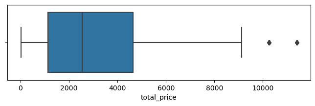

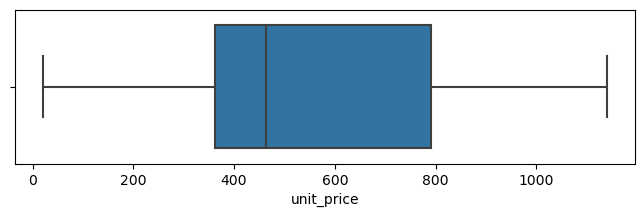

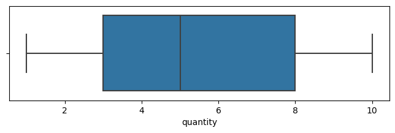

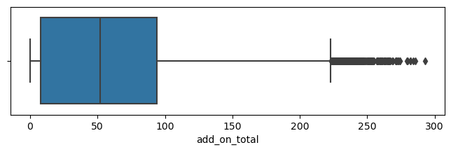

```python
# create boxplot of quantitative features to check for potential outliers
quan_features = ['total_price', 'unit_price', 'quantity', 'add_on_total']
for feature in quan_features:
    plt.figure(figsize=(8,2))
    sns.boxplot(x=df[feature])
    plt.show()
```

The boxplots above show that there are outliers for the `total_price` and `add_on_total`.  
Before decide whether to remove the outliers, it would be useful to investigate how many rows in the data contain outliers in the `total_price` and `add_on_total` columns.

```python
# determine the number of rows containing outliers
outlier_features = ['total_price', 'add_on_total']

for feature in outlier_features:
    # compute the interquantile range
    percentile25 = df[feature].quantile(0.25)
    percentile75 = df[feature].quantile(0.75)
    iqr = percentile75 - percentile25

    # define the upper and lower limit for non-outlier values
    upper_limit = percentile75 + 1.5 * iqr
    lower_limit = percentile25 - 1.5 * iqr

    # identify subset of data containing outliers
    outliers = df[(df[feature] > upper_limit) | (df[feature] < lower_limit)]

    # Count how many rows in the data contain outliers in `tenure`
    print(f"Number of rows in the data containing outliers in '{feature}': {len(outliers)}")
    print(f"Percentage of rows in the data containing outliers in '{feature}': {round(len(outliers)/20000*100, 2)}%")
```

```
Number of rows in the data containing outliers in 'total_price': 383
Percentage of rows in the data containing outliers in 'total_price': 1.92%
Number of rows in the data containing outliers in 'add_on_total': 249
Percentage of rows in the data containing outliers in 'add_on_total': 1.24%
```

After further investigation and taking the context of the data into consideration, it appears more beneficial to retain the outliers in the analysis.

- Outliers in the `total_price` and `add_on_total` features can offer valuable insights into the behavior of customer spending. These outliers may represent premium buyers or those willing to invest significantly in certain products or add-ons, which could inform strategies for targeting high-value customers or add-on sales.
- Furthermore, based on the above analysis, it appears that outliers in both `total_price` and `add_on_total` only represent 1.92% and 1.24% of the data set respectively. This means that by retaining the outliers in the data set, we are not expecting the outliers to significantly influence or impact the desciptive statistics of the data set.

Hence for this particular project, we will not be removing the outliers in the data set.

## Step 3. Data Exploration and Analysis

### Gather basic information about the data

```python
df.info()
```

```
<class 'pandas.core.frame.DataFrame'>
Index: 19999 entries, 0 to 19998
Data columns (total 16 columns):
 #   Column             Non-Null Count  Dtype
---  ------             --------------  -----
 0   customer_id        19999 non-null  int64
 1   age                19999 non-null  int64
 2   gender             19999 non-null  object
 3   loyalty_member     19999 non-null  object
 4   product_type       19999 non-null  object
 5   sku                19999 non-null  object
 6   rating             19999 non-null  int64
 7   order_status       19999 non-null  object
 8   payment_method     19999 non-null  object
 9   total_price        19999 non-null  float64
 10  unit_price         19999 non-null  float64
 11  quantity           19999 non-null  int64
 12  purchase_date      19999 non-null  object
 13  shipping_type      19999 non-null  object
 14  add_ons_purchased  15132 non-null  object
 15  add_on_total       19999 non-null  float64
dtypes: float64(3), int64(4), object(9)
memory usage: 2.6+ MB
```

### Gather descriptive statistics about the data

```python
df.describe()
```

|  | customer_id | age | rating | total_price | unit_price | quantity | add_on_total |
| --- | --- | --- | --- | --- | --- | --- | --- |
| count | 19999.000000 | 19999.000000 | 19999.000000 | 19999.000000 | 19999.000000 | 19999.000000 | 19999.000000 |
| mean | 10483.050803 | 48.995200 | 3.093905 | 3180.258715 | 578.627082 | 5.485774 | 62.247960 |
| std | 5631.471413 | 18.038526 | 1.223778 | 2544.980615 | 312.281150 | 2.870751 | 58.058214 |
| min | 1000.000000 | 18.000000 | 1.000000 | 20.750000 | 20.750000 | 1.000000 | 0.000000 |
| 25% | 5478.000000 | 33.000000 | 2.000000 | 1139.680000 | 361.180000 | 3.000000 | 7.625000 |
| 50% | 9999.000000 | 49.000000 | 3.000000 | 2534.490000 | 463.960000 | 5.000000 | 51.700000 |
| 75% | 15503.500000 | 65.000000 | 4.000000 | 4639.600000 | 791.190000 | 8.000000 | 93.845000 |
| max | 19997.000000 | 80.000000 | 5.000000 | 11396.800000 | 1139.680000 | 10.000000 | 292.770000 |

### Scatterplot Matrix

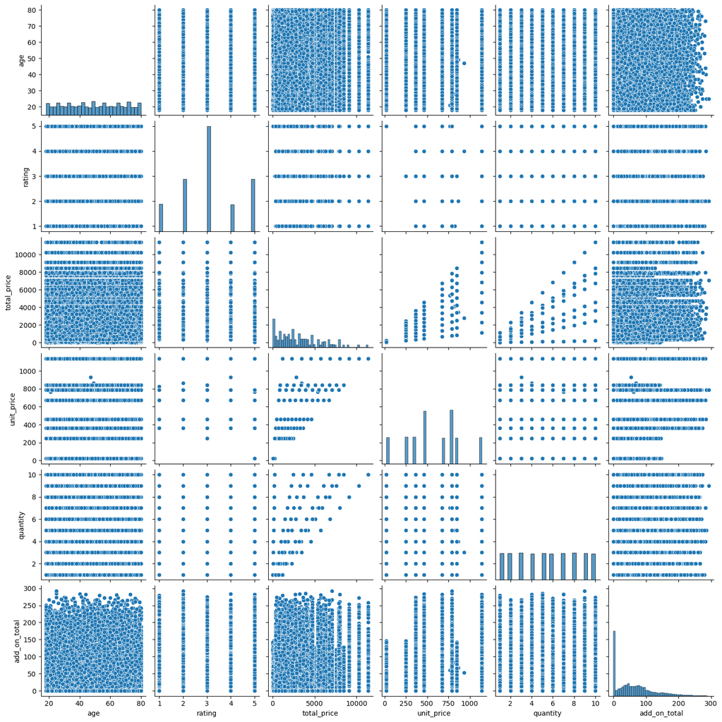

```python
# suppress the FutureWarning as there are no inf values in data set
warnings.filterwarnings("ignore", category=FutureWarning)

# scatterplot matrix
df_filtered = df.drop(columns=['customer_id'])
sns.pairplot(df_filtered)
```

Now that we have a better understanding of the correlations between the features, we need to further investigate specific features that are of particular interest and have the potential to provide valuable insights for our sales strategy. This involves focusing on key features such as `gender`, `product_type`, `payment_method` and etc, which may influence purchasing behavior, preferences and satisfaction which can give us a better clue on the possible sales strategy that can be effective.

### Features

[figure not shown]

```python
# feature counts
key_features = ['gender', 'product_type', 'payment_method', 'loyalty_member', 'shipping_type', 'order_status']

fig, axes = plt.subplots(2, 3, figsize=(18, 10))
axes = axes.flatten()

for ax, feature in zip(axes, key_features):
    counts = df[feature].value_counts()
    bar_plot = sns.barplot(x=counts.index, y=counts.values, palette='pastel', ax=ax)

    # Annotate bars with their heights
    for p in bar_plot.patches:
        bar_plot.annotate(f'{int(p.get_height())}',
                          (p.get_x() + p.get_width() / 2., p.get_height()),
                          ha='center', va='bottom')

    ax.set_title(f'Counts for {feature}')
    ax.set_ylabel('Counts')
    ax.set_xlabel(feature.capitalize())
    ax.set_xticklabels(counts.index, rotation=0)
    ax.grid(axis='y', linestyle='--', alpha=0.7)

# Adjust layout
plt.tight_layout()

# Show the plots
plt.show()
```

After conducting a deeper analysis of the features, we identify that the variation in the sales volume across different product types and payment methods suggests the potential for developing targeted sales strategies in these 2 areas. By understanding the preferences and behaviors associated with product types and payment methods, businesses can craft focused marketing campaigns and promotional offers to better meet customer needs and drive higher conversions.

Product Type Insights

- Based on the barchart above, there are significant lower number of headphones that are being sold as compared to the other product types.
- Headphone sales are 66% lower than smartphone sales
- Possible to leavage on smartphone sales to boost headphone sales
- One possible strategy is to introduce promotional bundles, combining smartphones and headphones at an attractive, discounted price to encourage customers to consider purchasing headphones as part of a bundled deal.

Payment Method Insights

- Based on the barchart above, the credit card and PayPal payment is the most popular type of payment method
- Strategy should focus on engaging the majority of potential customers who are likely to be using these two payment methods to encourage purchases.
- One possible strategy is to collaborate with credit card companies to create co-branded loyalty programs that reward customers with points or benefits for using their cards

Further analysis can be conducted for the other features as well to brainstorm more possible strategy to boost sales.

### Bivariate Analysis

Analysis of 2 features can also give more insights, and potentially more targeted solutions to boost sales.

```python
df.groupby(['payment_method', 'gender']).size()
```

```
payment_method  gender
Bank Transfer   Female    1592
                Male      1778
Cash            Female    1287
                Male      1205
Credit Card     Female    2871
                Male      2997
Debit Card      Female    1232
                Male      1239
PayPal          Female    2853
                Male      2945
dtype: int64
```

```python
df.groupby(['product_type', 'payment_method']).size()
```

```
product_type  payment_method
Headphones    Bank Transfer      692
              Credit Card        681
              Debit Card           1
              PayPal             637
Laptop        Bank Transfer      638
              Cash               485
              Credit Card       1157
              Debit Card         530
              PayPal            1162
Smartphone    Bank Transfer      683
              Cash               985
              Credit Card       1683
              Debit Card         948
              PayPal            1679
Smartwatch    Bank Transfer      641
              Cash               480
              Credit Card       1175
              Debit Card         493
              PayPal            1145
Tablet        Bank Transfer      716
              Cash               542
              Credit Card       1172
              Debit Card         499
              PayPal            1175
dtype: int64
```

```python
df.groupby(['order_status', 'rating']).size()
```

```
order_status  rating
Cancelled     1          669
              2         1330
              3         2624
              4          653
              5         1292
Completed     1         1392
              2         2642
              3         5339
              4         1381
              5         2677
dtype: int64
```

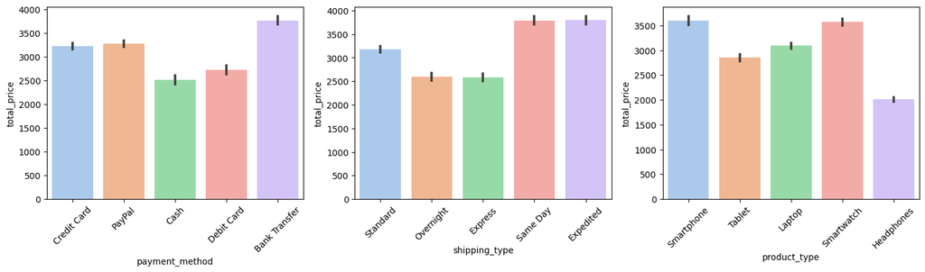

```python
bivariable1 = ['payment_method', 'total_price']
bivariable2 = ['shipping_type', 'total_price']
bivariable3 = ['product_type', 'total_price']

fig, axes = plt.subplots(1, 3, figsize=(18, 4))
axes = axes.flatten()

for ax, variables in zip(axes, [bivariable1, bivariable2, bivariable3]):
    sns.barplot(data=df, x=variables[0], y=variables[1], palette='pastel', ax=ax)
    ax.set_xticks(ax.get_xticks())
    ax.set_xticklabels(ax.get_xticklabels(), rotation=45)
```

### Time Series Analysis

```python
# create purchase_month column
df['purchase_date'] = pd.to_datetime(df['purchase_date'])
df['purchase_month'] = df['purchase_date'].dt.strftime('%B')

# create total_revenue column
df['total_revenue'] = df['total_price'] + df['add_on_total']

# verify new columns have been created
df.head()
```

|  | customer_id | age | gender | loyalty_member | product_type | sku | rating | order_status | payment_method | total_price | unit_price | quantity | purchase_date | shipping_type | add_ons_purchased | add_on_total | purchase_month | total_revenue |
| --- | --- | --- | --- | --- | --- | --- | --- | --- | --- | --- | --- | --- | --- | --- | --- | --- | --- | --- |
| 0 | 1000 | 53 | Male | No | Smartphone | SKU1004 | 2 | Cancelled | Credit Card | 5538.33 | 791.19 | 7 | 2024-03-20 | Standard | Accessory,Accessory,Accessory | 40.21 | March | 5578.54 |
| 1 | 1000 | 53 | Male | No | Tablet | SKU1002 | 3 | Completed | PayPal | 741.09 | 247.03 | 3 | 2024-04-20 | Overnight | Impulse Item | 26.09 | April | 767.18 |
| 2 | 1002 | 41 | Male | No | Laptop | SKU1005 | 3 | Completed | Credit Card | 1855.84 | 463.96 | 4 | 2023-10-17 | Express | NaN | 0.00 | October | 1855.84 |
| 3 | 1002 | 41 | Male | Yes | Smartphone | SKU1004 | 2 | Completed | Cash | 3164.76 | 791.19 | 4 | 2024-08-09 | Overnight | Impulse Item,Impulse Item | 60.16 | August | 3224.92 |
| 4 | 1003 | 75 | Male | Yes | Smartphone | SKU1001 | 5 | Completed | Cash | 41.50 | 20.75 | 2 | 2024-05-21 | Express | Accessory | 35.56 | May | 77.06 |

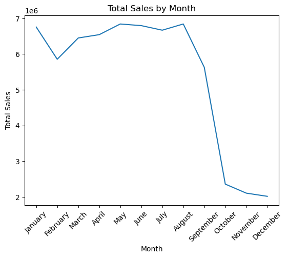

```python
# analyse sales over time
month_order = ['January', 'February', 'March', 'April', 'May', 'June', 'July', 'August', 'September', 'October', 'November', 'December']
monthly_sales = df.groupby('purchase_month')['total_revenue'].sum().reindex(month_order)

sns.lineplot(x=monthly_sales.index, y=monthly_sales)
plt.xticks(rotation=45)
plt.title('Total Sales by Month')
plt.ylabel('Total Sales')
plt.xlabel('Month')
plt.show()
```

From the line plot, it is evident that sales experience a significant dip during the months of October, November, and December. This decline could be attributed to various factors, such as seasonality, reduced customer demand, or ineffective marketing strategies during these months. Given that these months typically coincide with the holiday season and major shopping events like Black Friday and Christmas, this is something the team can leavage on to boost sales.

```python
df.head()
```

|  | customer_id | age | gender | loyalty_member | product_type | sku | rating | order_status | payment_method | total_price | unit_price | quantity | purchase_date | shipping_type | add_ons_purchased | add_on_total | purchase_month | total_revenue |
| --- | --- | --- | --- | --- | --- | --- | --- | --- | --- | --- | --- | --- | --- | --- | --- | --- | --- | --- |
| 0 | 1000 | 53 | Male | No | Smartphone | SKU1004 | 2 | Cancelled | Credit Card | 5538.33 | 791.19 | 7 | 2024-03-20 | Standard | Accessory,Accessory,Accessory | 40.21 | March | 5578.54 |
| 1 | 1000 | 53 | Male | No | Tablet | SKU1002 | 3 | Completed | PayPal | 741.09 | 247.03 | 3 | 2024-04-20 | Overnight | Impulse Item | 26.09 | April | 767.18 |
| 2 | 1002 | 41 | Male | No | Laptop | SKU1005 | 3 | Completed | Credit Card | 1855.84 | 463.96 | 4 | 2023-10-17 | Express | NaN | 0.00 | October | 1855.84 |
| 3 | 1002 | 41 | Male | Yes | Smartphone | SKU1004 | 2 | Completed | Cash | 3164.76 | 791.19 | 4 | 2024-08-09 | Overnight | Impulse Item,Impulse Item | 60.16 | August | 3224.92 |
| 4 | 1003 | 75 | Male | Yes | Smartphone | SKU1001 | 5 | Completed | Cash | 41.50 | 20.75 | 2 | 2024-05-21 | Express | Accessory | 35.56 | May | 77.06 |

## Step 4. Conclusion

Our comprehensive analysis of the sales data has revealed key areas to focus our sales strategy to effectively boost overall electronics sales.

One significant opportunity lies in enhancing credit card promotions for headphones during the year-end holiday season. This period has historically correlated with lower sales for this category, which we have identified as less popular among consumers. By leveraging credit cards, the most common payment method, we can design enticing promotional offers that encourage customers to consider these products. Additionally, we recommend tailoring our marketing efforts to emphasize the unique features and benefits of headphones, positioning them as essential accessories during holiday shopping. By integrating our insights with targeted promotions, we can stimulate sales during typically slow periods while also enhancing overall customer engagement and satisfaction.

It is important to note that this project primarily focuses on using visualization and insights to develop potential solutions. In a real-world context, where more extensive data may be available, we could conduct more in-depth and sophisticated analyses, such as machine learning and statistical modeling. These advanced techniques would not only help us gain deeper insights but also enable us to make predictive analyses about future sales trends.